# Reconocimiento de emociones

En este archivo se presentarán diversas alternativas para el reconocimiento y análisis de emociones en Hilos de diferente largo.

Para comodidad del lector primero se analizará solo un tweet, luego de presentar el método de análisis se procederá a trabajar todo el dataset.

## Importación de liberias y apertura de archivos

```python
import os
import random
import pandas as pd
```

```python
from bokeh.io import output_notebook, show
from bokeh.plotting import figure
from bokeh.models import Span

output_notebook()
```

```python
from emotion_predictor import EmotionPredictor
```

```
Using Theano backend.
```

```python
csv1 = pd.read_csv('five_ten.csv', encoding='iso-8859-1')
csv1_grouped_by_thread = csv1.groupby(['thread_number'])
threads1 = {}
kthreads1 = {}

csv2 = pd.read_csv('ten_fifteen.csv', encoding='iso-8859-1')
csv2_grouped_by_thread = csv2.groupby(['thread_number'])
threads2 = {}
kthreads2 = {}

csv3 = pd.read_csv('fifteen_twenty.csv', encoding='iso-8859-1')
csv3_grouped_by_thread = csv3.groupby(['thread_number'])
threads3 = {}
kthreads3 = {}

csv4 = pd.read_csv('twenty_twentyfive.csv', encoding='iso-8859-1')
csv4_grouped_by_thread = csv4.groupby(['thread_number'])
threads4 = {}
kthreads4 = {}

csv5 = pd.read_csv('twentyfive_thirty.csv', encoding='iso-8859-1')
csv5_grouped_by_thread = csv5.groupby(['thread_number'])
threads5 = {}
kthreads5 = {}
```

## Threads como diccionario y como arreglo de string

Se tienen dos formatos para trabajar los datos. El primero es como un diccionario de threads, el cual la clave es el numero de thread y el valor es un arreglo de strings con todos los tweets del thread. La otra es un arreglo de strings, los cuales son todos los tweets unidos en orden separados con un \n

```python
string = '\n'

for thread, data in dict(list(csv1_grouped_by_thread)).items():
    threads1[thread] = list(data['text'])
    kthreads1[thread] = string.join(list(data['text']))

for thread, data in dict(list(csv2_grouped_by_thread)).items():
    threads2[thread] = list(data['text'])
    kthreads2[thread] = string.join(list(data['text']))


for thread, data in dict(list(csv3_grouped_by_thread)).items():
    threads3[thread] = list(data['text'])
    kthreads3[thread] = string.join(list(data['text']))


for thread, data in dict(list(csv4_grouped_by_thread)).items():
    threads4[thread] = list(data['text'])
    kthreads4[thread] = string.join(list(data['text']))


for thread, data in dict(list(csv5_grouped_by_thread)).items():
    threads5[thread] = list(data['text'])
    kthreads5[thread] = string.join(list(data['text']))


Tthreads1 = list(kthreads1.values())
Tthreads2 = list(kthreads2.values())
Tthreads3 = list(kthreads3.values())
Tthreads4 = list(kthreads4.values())
Tthreads5 = list(kthreads5.values())
```

```python
threads1["Thread 1"]
```

```
['Extraordinary evidence at Treasury committee from Jon Thompson, CEO of HMRC on customs and Brexit today https://t.co/DJhIQhmVwJ',
 "The Brexiter favourite Max Fac - would cost business between Â£17 and Â£20bn a year\r\r\n\r\r\n- that's almost 1% of GDP\r\r\n\r\r\n- jusâ?¦ https://t.co/0MwIcwre4t",
 'How does he arrive at the figure\r\r\n\r\r\n200m export consignments at an average cost of Â£32.50 each = Â£6.5bn (times two beâ?¦ https://t.co/KxnkU2QiVO',
 "Theresa May's New Customs Partnership is much cheaper for business (almost zero cost)  because it seeks to replicatâ?¦ https://t.co/0LcsJHah0H",
 'Mr Thompson said he did not expect the EU to reciprocate over the customs partnership. \r\r\n\r\r\nWhat that means is UK collâ?¦ https://t.co/9c3uhhnZGX',
 'Both would not be ready by 2021. Max Fac needs 3 years. Customs Partnership requires 5, Mr Thompson said.\r\r\n\r\r\nThe bordâ?¦ https://t.co/luLzgUsiR4',
 '"We think we can manage the risk - we think we can" he said. He didn\'t sound so sure. \r\r\n\r\r\nAnd "the potential backdoorâ?¦ https://t.co/Ti1nbbjfpU']
```

```python
kthreads1
```

[output not shown]

[output cut: 84 more lines]

```python
Tthreads1
```

[output not shown]

[output cut: 84 more lines]

```python
df_unidos1 = pd.DataFrame.from_dict(kthreads1, orient='index', columns=['Tweet'])
df_unidos2 = pd.DataFrame.from_dict(kthreads2, orient='index', columns=['Tweet'])
df_unidos3 = pd.DataFrame.from_dict(kthreads3, orient='index', columns=['Tweet'])
df_unidos4 = pd.DataFrame.from_dict(kthreads4, orient='index', columns=['Tweet'])
df_unidos5 = pd.DataFrame.from_dict(kthreads5, orient='index', columns=['Tweet'])

df_unidos1.index.name = "Hilo"
df_unidos1.reset_index(inplace=True)

df_unidos2.index.name = "Hilo"
df_unidos2.reset_index(inplace=True)

df_unidos3.index.name = "Hilo"
df_unidos3.reset_index(inplace=True)

df_unidos4.index.name = "Hilo"
df_unidos4.reset_index(inplace=True)

df_unidos5.index.name = "Hilo"
df_unidos5.reset_index(inplace=True)

df_unidos1.head()
```

|  | Hilo | Tweet |
| --- | --- | --- |
| 0 | Thread 1 | Extraordinary evidence at Treasury committee f... |
| 1 | Thread 10 | Here are some real ideas to fix the #immigrati... |
| 2 | Thread 100 | This is such a shocking story in its details.\... |
| 3 | Thread 101 | 1) Attribution to an #Anon. Not wholly my wor... |
| 4 | Thread 11 | Part 1: March 9ish. An excited #Qanon breaks d... |

## Detección de emociones.

Se importa el modelo a utilizar para la detección de emociones. Se trabajará con las emociones definidas por Ekman.

Se extraerán dos emociones por hilo, esto para posibles futuros análisis.

Existen dos alternativas para el output las emociones. La primera es a través de la predicción directa de la emoción, la cual entrega una tabla con la emoción principal de cada documento estudiado. La segunda es a través de una matriz de probabilidades, en la cual las columnas son las emociones y las filas los documentos a analizar. Cada valor de la matríz es la probabilidad de que el documento sea asociado a esa emoción.

```python
ekman = EmotionPredictor(classification='ekman', setting='mc')
```

```python
tweets = threads1["Thread 1"]
matriz = ekman.predict_probabilities(tweets)
tabla = ekman.predict_classes(tweets)
```

```python
matriz
```

|  | Tweet | Anger | Disgust | Fear | Joy | Sadness | Surprise |
| --- | --- | --- | --- | --- | --- | --- | --- |
| 0 | Extraordinary evidence at Treasury committee f... | 0.005198 | 0.002203 | 0.022643 | 0.673286 | 0.009532 | 0.287138 |
| 1 | The Brexiter favourite Max Fac - would cost bu... | 0.013784 | 0.007089 | 0.054312 | 0.482430 | 0.112748 | 0.329637 |
| 2 | How does he arrive at the figure\r\r\n\r\r\n20... | 0.074924 | 0.011434 | 0.400213 | 0.295159 | 0.069761 | 0.148510 |
| 3 | Theresa May's New Customs Partnership is much ... | 0.012332 | 0.036829 | 0.179175 | 0.090255 | 0.018078 | 0.663330 |
| 4 | Mr Thompson said he did not expect the EU to r... | 0.030329 | 0.017072 | 0.060771 | 0.088922 | 0.277415 | 0.525490 |
| 5 | Both would not be ready by 2021. Max Fac needs... | 0.015301 | 0.005518 | 0.113649 | 0.403367 | 0.097253 | 0.364913 |
| 6 | "We think we can manage the risk - we think we... | 0.025122 | 0.007756 | 0.403552 | 0.187179 | 0.057420 | 0.318970 |

```python
matriz.describe()
```

|  | Anger | Disgust | Fear | Joy | Sadness | Surprise |
| --- | --- | --- | --- | --- | --- | --- |
| count | 7.000000 | 7.000000 | 7.000000 | 7.000000 | 7.000000 | 7.000000 |
| mean | 0.025284 | 0.012557 | 0.176331 | 0.317228 | 0.091744 | 0.376856 |
| std | 0.023426 | 0.011694 | 0.162046 | 0.216998 | 0.090178 | 0.168362 |
| min | 0.005198 | 0.002203 | 0.022643 | 0.088922 | 0.009532 | 0.148510 |
| 25% | 0.013058 | 0.006303 | 0.057542 | 0.138717 | 0.037749 | 0.303054 |
| 50% | 0.015301 | 0.007756 | 0.113649 | 0.295159 | 0.069761 | 0.329637 |
| 75% | 0.027726 | 0.014253 | 0.289694 | 0.442898 | 0.105001 | 0.445201 |
| max | 0.074924 | 0.036829 | 0.403552 | 0.673286 | 0.277415 | 0.663330 |

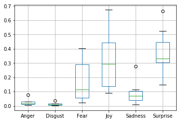

```python
matriz.boxplot(column = ["Anger", "Disgust", "Fear", "Joy", "Sadness", "Surprise"])
```

```python
grafico = figure(plot_width=700,
           plot_height=350,
           title='Probabilidad de cada emoción por tweet',
           background_fill_color="#f2f3f7",
           y_axis_label='probabilidad',
           x_axis_label='Tweets along the thread')

grafico.line(list(range(1,8)), matriz['Anger'].values,line_color='#cd2626', legend='Enojo')
grafico.line(list(range(1,8)), matriz['Disgust'].values, line_color='#64bd40', legend='Disgusto')
grafico.line(list(range(1,8)), matriz['Fear'].values, line_color='#cbbeb5', legend='Miedo')
grafico.line(list(range(1,8)), matriz['Joy'].values, line_color='#ffe700', legend='Alegria')
grafico.line(list(range(1,8)), matriz['Sadness'].values, line_color='#7cb890', legend='Pena')
grafico.line(list(range(1,8)), matriz['Surprise'].values, line_color='#ff00db', legend='Sorpresa')

show(grafico)
```

[interactive chart not shown]

```python
tabla
```

|  | Tweet | Emotion |
| --- | --- | --- |
| 0 | Extraordinary evidence at Treasury committee f... | Joy |
| 1 | The Brexiter favourite Max Fac - would cost bu... | Joy |
| 2 | How does he arrive at the figure\r\r\n\r\r\n20... | Fear |
| 3 | Theresa May's New Customs Partnership is much ... | Surprise |
| 4 | Mr Thompson said he did not expect the EU to r... | Surprise |
| 5 | Both would not be ready by 2021. Max Fac needs... | Joy |
| 6 | "We think we can manage the risk - we think we... | Fear |

```python
tabla.describe()
```

|  | Tweet | Emotion |
| --- | --- | --- |
| count | 7 | 7 |
| unique | 7 | 3 |
| top | Extraordinary evidence at Treasury committee f... | Joy |
| freq | 1 | 3 |

## Análisis de emociones según la matriz de probabilidades.

Se poseen varias alternativas para obtener la emoción del thread a través de la matriz, los cuales serán descritos a continuación:

```python
matriz_valores = matriz.drop(columns ="Tweet")
matriz_valores
```

|  | Anger | Disgust | Fear | Joy | Sadness | Surprise |
| --- | --- | --- | --- | --- | --- | --- |
| 0 | 0.005198 | 0.002203 | 0.022643 | 0.673286 | 0.009532 | 0.287138 |
| 1 | 0.013784 | 0.007089 | 0.054312 | 0.482430 | 0.112748 | 0.329637 |
| 2 | 0.074924 | 0.011434 | 0.400213 | 0.295159 | 0.069761 | 0.148510 |
| 3 | 0.012332 | 0.036829 | 0.179175 | 0.090255 | 0.018078 | 0.663330 |
| 4 | 0.030329 | 0.017072 | 0.060771 | 0.088922 | 0.277415 | 0.525490 |
| 5 | 0.015301 | 0.005518 | 0.113649 | 0.403367 | 0.097253 | 0.364913 |
| 6 | 0.025122 | 0.007756 | 0.403552 | 0.187179 | 0.057420 | 0.318970 |

### Emoción media

Se definió como emoción media a la columna que posea el promedio más alto.

```python
matriz_media = matriz_valores.mean().to_frame().transpose()
matriz_media
```

|  | Anger | Disgust | Fear | Joy | Sadness | Surprise |
| --- | --- | --- | --- | --- | --- | --- |
| 0 | 0.025284 | 0.012557 | 0.176331 | 0.317228 | 0.091744 | 0.376856 |

```python
matriz_media.sort_values(by = 0, axis = 1, ascending=False)
```

|  | Surprise | Joy | Fear | Sadness | Anger | Disgust |
| --- | --- | --- | --- | --- | --- | --- |
| 0 | 0.376856 | 0.317228 | 0.176331 | 0.091744 | 0.025284 | 0.012557 |

```python
matriz_emociones_media_max = list(matriz_media.sort_values(by = 0, axis = 1, ascending=False).iloc[:,0:2])
matriz_emociones_media_max
```

```
['Surprise', 'Joy']
```

### Emoción más intensa

Se definió como emoción más intensa a la columna que posea el valor máximo más alto de todos.

```python
matriz_emocion = matriz_valores.max().to_frame().transpose().sort_values(by = 0, axis = 1, ascending=False)
matriz_emocion
```

|  | Joy | Surprise | Fear | Sadness | Anger | Disgust |
| --- | --- | --- | --- | --- | --- | --- |
| 0 | 0.673286 | 0.66333 | 0.403552 | 0.277415 | 0.074924 | 0.036829 |

```python
matriz_emociones_max = list(matriz_emocion.sort_values(by = 0, axis = 1, ascending=False).iloc[:,0:2])
matriz_emociones_max
```

```
['Joy', 'Surprise']
```

## Análisis de emociones según la tabla de emociones.

Para analizar las emociones según la tabla es posible considerar la frecuencia en la que aparecen las emociones.

### Emoción Moda

Se definió como emoción moda como la emoción que presenta la mayor frecuencia de aparición

```python
tabla.Emotion.value_counts().to_frame().transpose()
```

|  | Joy | Surprise | Fear |
| --- | --- | --- | --- |
| Emotion | 3 | 2 | 2 |

```python
tabla_emociones_moda = list(tabla.Emotion.value_counts().to_frame().transpose().iloc[:,0:2])
tabla_emociones_moda
```

```
['Joy', 'Surprise']
```

# Estudio de threads como un solo documento

Para estudiar los threads como un sólo documento, se unieron los tweets y luego se ingresó el dataset completo como una colección de documentos. cada fila es un thread y cada columna es la probabilidad de una emoción específica. En este caso solo se posee una forma de analizar las emociones.

### Emoción Hilo

Al existir sólo un arreglo de probabilidades para cada thread, la emoción con mayor probabilidad y la emoción en la tabla es la misma, por lo que de este caso sólo se pueden obtener las primeras 2 emociones más probables para cada thread.

```python
Ttweets = Tthreads1
Tmatriz = ekman.predict_probabilities(Ttweets).drop(columns = "Tweet")

for index, row in Tmatriz.iterrows():
    Tmatriz_emocion = row.to_frame().transpose().sort_values(by = index, axis = 1, ascending=False)
    Tmatriz_emocion_max = list(Tmatriz_emocion.iloc[:,0:2])
    print(Tmatriz_emocion_max)
```

```
['Fear', 'Joy']
['Joy', 'Fear']
['Joy', 'Surprise']
['Fear', 'Surprise']
['Sadness', 'Fear']
['Anger', 'Joy']
['Sadness', 'Anger']
['Joy', 'Anger']
['Joy', 'Surprise']
['Joy', 'Fear']
['Fear', 'Surprise']
['Fear', 'Joy']
['Fear', 'Anger']
['Joy', 'Fear']
['Fear', 'Joy']
['Joy', 'Fear']
['Joy', 'Surprise']
['Fear', 'Joy']
['Joy', 'Surprise']
['Surprise', 'Joy']
['Fear', 'Joy']
['Joy', 'Fear']
['Fear', 'Joy']
['Anger', 'Surprise']
['Surprise', 'Joy']
['Fear', 'Surprise']
['Anger', 'Fear']
['Fear', 'Joy']
['Fear', 'Joy']
['Disgust', 'Fear']
['Disgust', 'Surprise']
['Joy', 'Fear']
['Fear', 'Joy']
['Joy', 'Fear']
['Joy', 'Fear']
['Fear', 'Joy']
['Surprise', 'Joy']
['Fear', 'Anger']
['Joy', 'Sadness']
['Joy', 'Sadness']
```

[output cut: 46 more lines]

```
['Surprise', 'Joy']
['Surprise', 'Anger']
['Joy', 'Fear']
['Joy', 'Surprise']
['Joy', 'Fear']
['Fear', 'Joy']
['Joy', 'Fear']
['Sadness', 'Joy']
['Joy', 'Fear']
['Anger', 'Fear']
['Fear', 'Surprise']
['Joy', 'Fear']
['Joy', 'Sadness']
['Fear', 'Surprise']
['Fear', 'Joy']
```

# Estudio del dataset completo por tweets separados.

Luego de presentar todos los métodos definidos para obtención la emoción para cada thread, se procede a calcularlos.

## CSV five_ten

```python
threads_estudio = threads1

tweets_analisis = []

emocion_media = []
emocion_presente = []
emocion_moda = []

etiquetas = ["Thread", "1ra Emocion", "2da Emocion"]


for hilo in threads_estudio:
    print(hilo)
    #Conseguir Emociones
    tweets_analisis = threads_estudio[hilo]
    matriz_hilo_analizado = ekman.predict_probabilities(tweets_analisis).drop(columns ="Tweet")
    tabla_hilo_analizado = ekman.predict_classes(tweets_analisis)

    #Emocion media
    matriz_media_analisis = matriz_hilo_analizado.mean().to_frame().transpose()
    matriz_emociones_media_max_analisis = list(matriz_media_analisis.sort_values(by = 0, axis = 1, ascending=False).iloc[:,0:2])
    matriz_emociones_media_max_analisis.insert(0, hilo)
    print(matriz_emociones_media_max_analisis)

    #Emocion mas intensa
    matriz_emocion_analisis = matriz_hilo_analizado.max().to_frame().transpose().sort_values(by = 0, axis = 1, ascending=False)
    matriz_emociones_max_analisis = list(matriz_emocion_analisis.sort_values(by = 0, axis = 1, ascending=False).iloc[:,0:2])
    matriz_emociones_max_analisis.insert(0, hilo)
    print(matriz_emociones_max_analisis)

    #Emocion moda
    tabla_emociones_moda_analisis = list(tabla_hilo_analizado.Emotion.value_counts().to_frame().transpose().iloc[:,0:2])
    tabla_emociones_moda_analisis.insert(0, hilo)
    print(tabla_emociones_moda_analisis)


    #Agregar a lista de listas

    emocion_media.append(matriz_emociones_media_max_analisis)
    emocion_presente.append(matriz_emociones_max_analisis)
    emocion_moda.append(tabla_emociones_moda_analisis)

# Creacion de dataframes
dataframe_emocion_media = pd.DataFrame.from_records(emocion_media, columns = etiquetas)
dataframe_emocion_presente = pd.DataFrame.from_records(emocion_presente, columns = etiquetas)
dataframe_emocion_moda = pd.DataFrame.from_records(emocion_moda, columns = etiquetas)

# Guardado de dataframes

dataframe_emocion_media_1 = dataframe_emocion_media
dataframe_emocion_presente_1 = dataframe_emocion_presente
dataframe_emocion_moda_1 = dataframe_emocion_moda
```

```
Thread 1
['Thread 1', 'Surprise', 'Joy']
['Thread 1', 'Joy', 'Surprise']
['Thread 1', 'Joy', 'Surprise']
Thread 10
['Thread 10', 'Joy', 'Fear']
['Thread 10', 'Joy', 'Fear']
['Thread 10', 'Surprise', 'Fear']
Thread 100
['Thread 100', 'Surprise', 'Fear']
['Thread 100', 'Surprise', 'Fear']
['Thread 100', 'Surprise', 'Fear']
Thread 101
['Thread 101', 'Surprise', 'Fear']
['Thread 101', 'Surprise', 'Fear']
['Thread 101', 'Surprise', 'Fear']
Thread 11
['Thread 11', 'Surprise', 'Joy']
['Thread 11', 'Sadness', 'Surprise']
['Thread 11', 'Surprise', 'Joy']
Thread 12
['Thread 12', 'Joy', 'Surprise']
['Thread 12', 'Joy', 'Surprise']
['Thread 12', 'Joy', 'Surprise']
Thread 13
['Thread 13', 'Surprise', 'Sadness']
['Thread 13', 'Anger', 'Sadness']
['Thread 13', 'Surprise', 'Sadness']
Thread 14
['Thread 14', 'Surprise', 'Fear']
['Thread 14', 'Surprise', 'Fear']
['Thread 14', 'Surprise', 'Fear']
Thread 15
['Thread 15', 'Surprise', 'Joy']
['Thread 15', 'Surprise', 'Joy']
['Thread 15', 'Joy', 'Surprise']
Thread 16
['Thread 16', 'Fear', 'Surprise']
['Thread 16', 'Fear', 'Surprise']
['Thread 16', 'Surprise', 'Fear']
```

[output cut: 349 more lines]

```
['Thread 96', 'Surprise', 'Fear']
['Thread 96', 'Surprise', 'Fear']
['Thread 96', 'Surprise', 'Fear']
Thread 97
['Thread 97', 'Surprise', 'Joy']
['Thread 97', 'Surprise', 'Joy']
['Thread 97', 'Surprise', 'Joy']
Thread 98
['Thread 98', 'Fear', 'Surprise']
['Thread 98', 'Fear', 'Surprise']
['Thread 98', 'Fear', 'Surprise']
Thread 99
['Thread 99', 'Surprise', 'Joy']
['Thread 99', 'Anger', 'Surprise']
['Thread 99', 'Surprise', 'Anger']
```

## CSV ten_fifteen

```python
threads_estudio = threads2

tweets_analisis = []

emocion_media = []
emocion_presente = []
emocion_moda = []

etiquetas = ["Thread", "1ra Emocion", "2da Emocion"]


for hilo in threads_estudio:
    print(hilo)
    #Conseguir Emociones
    tweets_analisis = threads_estudio[hilo]
    matriz_hilo_analizado = ekman.predict_probabilities(tweets_analisis).drop(columns ="Tweet")
    tabla_hilo_analizado = ekman.predict_classes(tweets_analisis)

    #Emocion media
    matriz_media_analisis = matriz_hilo_analizado.mean().to_frame().transpose()
    matriz_emociones_media_max_analisis = list(matriz_media_analisis.sort_values(by = 0, axis = 1, ascending=False).iloc[:,0:2])
    matriz_emociones_media_max_analisis.insert(0, hilo)
    print(matriz_emociones_media_max_analisis)

    #Emocion mas intensa
    matriz_emocion_analisis = matriz_hilo_analizado.max().to_frame().transpose().sort_values(by = 0, axis = 1, ascending=False)
    matriz_emociones_max_analisis = list(matriz_emocion_analisis.sort_values(by = 0, axis = 1, ascending=False).iloc[:,0:2])
    matriz_emociones_max_analisis.insert(0, hilo)
    print(matriz_emociones_max_analisis)

    #Emocion moda
    tabla_emociones_moda_analisis = list(tabla_hilo_analizado.Emotion.value_counts().to_frame().transpose().iloc[:,0:2])
    tabla_emociones_moda_analisis.insert(0, hilo)
    print(tabla_emociones_moda_analisis)


    #Agregar a lista de listas

    emocion_media.append(matriz_emociones_media_max_analisis)
    emocion_presente.append(matriz_emociones_max_analisis)
    emocion_moda.append(tabla_emociones_moda_analisis)

# Creacion de dataframes
dataframe_emocion_media = pd.DataFrame.from_records(emocion_media, columns = etiquetas)
dataframe_emocion_presente = pd.DataFrame.from_records(emocion_presente, columns = etiquetas)
dataframe_emocion_moda = pd.DataFrame.from_records(emocion_moda, columns = etiquetas)

# Guardado de dataframes

dataframe_emocion_media_2 = dataframe_emocion_media
dataframe_emocion_presente_2 = dataframe_emocion_presente
dataframe_emocion_moda_2 = dataframe_emocion_moda
```

```
Thread 1
['Thread 1', 'Surprise', 'Fear']
['Thread 1', 'Fear', 'Surprise']
['Thread 1', 'Surprise', 'Fear']
Thread 10
['Thread 10', 'Surprise', 'Joy']
['Thread 10', 'Surprise', 'Fear']
['Thread 10', 'Surprise', 'Joy']
Thread 11
['Thread 11', 'Surprise', 'Joy']
['Thread 11', 'Joy', 'Surprise']
['Thread 11', 'Surprise', 'Joy']
Thread 12
['Thread 12', 'Joy', 'Surprise']
['Thread 12', 'Joy', 'Surprise']
['Thread 12', 'Joy', 'Surprise']
Thread 13
['Thread 13', 'Surprise', 'Joy']
['Thread 13', 'Surprise', 'Fear']
['Thread 13', 'Surprise', 'Fear']
Thread 14
['Thread 14', 'Surprise', 'Joy']
['Thread 14', 'Surprise', 'Joy']
['Thread 14', 'Surprise', 'Sadness']
Thread 15
['Thread 15', 'Joy', 'Surprise']
['Thread 15', 'Joy', 'Surprise']
['Thread 15', 'Joy', 'Surprise']
Thread 16
['Thread 16', 'Surprise', 'Joy']
['Thread 16', 'Surprise', 'Joy']
['Thread 16', 'Joy', 'Surprise']
Thread 17
['Thread 17', 'Joy', 'Surprise']
['Thread 17', 'Surprise', 'Joy']
['Thread 17', 'Joy', 'Surprise']
Thread 18
['Thread 18', 'Fear', 'Surprise']
['Thread 18', 'Joy', 'Fear']
['Thread 18', 'Fear', 'Surprise']
```

[output cut: 337 more lines]

```
['Thread 95', 'Surprise', 'Fear']
['Thread 95', 'Joy', 'Surprise']
['Thread 95', 'Surprise', 'Fear']
Thread 96
['Thread 96', 'Joy', 'Surprise']
['Thread 96', 'Joy', 'Surprise']
['Thread 96', 'Sadness', 'Surprise']
Thread 97
['Thread 97', 'Fear', 'Surprise']
['Thread 97', 'Surprise', 'Fear']
['Thread 97', 'Fear', 'Surprise']
Thread 98
['Thread 98', 'Fear', 'Surprise']
['Thread 98', 'Surprise', 'Fear']
['Thread 98', 'Sadness', 'Fear']
```

## CSV fifteen_twenty

```python
threads_estudio = threads3

tweets_analisis = []

emocion_media = []
emocion_presente = []
emocion_moda = []

etiquetas = ["Thread", "1ra Emocion", "2da Emocion"]


for hilo in threads_estudio:
    print(hilo)
    #Conseguir Emociones
    tweets_analisis = threads_estudio[hilo]
    matriz_hilo_analizado = ekman.predict_probabilities(tweets_analisis).drop(columns ="Tweet")
    tabla_hilo_analizado = ekman.predict_classes(tweets_analisis)

    #Emocion media
    matriz_media_analisis = matriz_hilo_analizado.mean().to_frame().transpose()
    matriz_emociones_media_max_analisis = list(matriz_media_analisis.sort_values(by = 0, axis = 1, ascending=False).iloc[:,0:2])
    matriz_emociones_media_max_analisis.insert(0, hilo)
    print(matriz_emociones_media_max_analisis)

    #Emocion mas intensa
    matriz_emocion_analisis = matriz_hilo_analizado.max().to_frame().transpose().sort_values(by = 0, axis = 1, ascending=False)
    matriz_emociones_max_analisis = list(matriz_emocion_analisis.sort_values(by = 0, axis = 1, ascending=False).iloc[:,0:2])
    matriz_emociones_max_analisis.insert(0, hilo)
    print(matriz_emociones_max_analisis)

    #Emocion moda
    tabla_emociones_moda_analisis = list(tabla_hilo_analizado.Emotion.value_counts().to_frame().transpose().iloc[:,0:2])
    tabla_emociones_moda_analisis.insert(0, hilo)
    print(tabla_emociones_moda_analisis)


    #Agregar a lista de listas

    emocion_media.append(matriz_emociones_media_max_analisis)
    emocion_presente.append(matriz_emociones_max_analisis)
    emocion_moda.append(tabla_emociones_moda_analisis)

# Creacion de dataframes
dataframe_emocion_media = pd.DataFrame.from_records(emocion_media, columns = etiquetas)
dataframe_emocion_presente = pd.DataFrame.from_records(emocion_presente, columns = etiquetas)
dataframe_emocion_moda = pd.DataFrame.from_records(emocion_moda, columns = etiquetas)

# Guardado de dataframes

dataframe_emocion_media_3 = dataframe_emocion_media
dataframe_emocion_presente_3 = dataframe_emocion_presente
dataframe_emocion_moda_3 = dataframe_emocion_moda
```

```
Thread 1
['Thread 1', 'Joy', 'Surprise']
['Thread 1', 'Joy', 'Surprise']
['Thread 1', 'Joy', 'Surprise']
Thread 10
['Thread 10', 'Surprise', 'Joy']
['Thread 10', 'Surprise', 'Joy']
['Thread 10', 'Surprise', 'Fear']
Thread 11
['Thread 11', 'Fear', 'Surprise']
['Thread 11', 'Surprise', 'Joy']
['Thread 11', 'Fear', 'Surprise']
Thread 12
['Thread 12', 'Surprise', 'Fear']
['Thread 12', 'Joy', 'Fear']
['Thread 12', 'Surprise', 'Fear']
Thread 13
['Thread 13', 'Fear', 'Surprise']
['Thread 13', 'Fear', 'Joy']
['Thread 13', 'Fear', 'Surprise']
Thread 14
['Thread 14', 'Surprise', 'Fear']
['Thread 14', 'Surprise', 'Joy']
['Thread 14', 'Surprise', 'Fear']
Thread 15
['Thread 15', 'Surprise', 'Joy']
['Thread 15', 'Joy', 'Fear']
['Thread 15', 'Surprise', 'Fear']
Thread 16
['Thread 16', 'Surprise', 'Joy']
['Thread 16', 'Surprise', 'Joy']
['Thread 16', 'Surprise', 'Joy']
Thread 17
['Thread 17', 'Surprise', 'Joy']
['Thread 17', 'Joy', 'Surprise']
['Thread 17', 'Surprise', 'Fear']
Thread 18
['Thread 18', 'Surprise', 'Joy']
['Thread 18', 'Surprise', 'Joy']
['Thread 18', 'Surprise']
```

[output cut: 341 more lines]

```
['Thread 96', 'Surprise', 'Fear']
['Thread 96', 'Surprise', 'Joy']
['Thread 96', 'Surprise', 'Fear']
Thread 97
['Thread 97', 'Surprise', 'Fear']
['Thread 97', 'Fear', 'Surprise']
['Thread 97', 'Surprise', 'Fear']
Thread 98
['Thread 98', 'Surprise', 'Joy']
['Thread 98', 'Joy', 'Surprise']
['Thread 98', 'Surprise', 'Joy']
Thread 99
['Thread 99', 'Surprise', 'Joy']
['Thread 99', 'Sadness', 'Joy']
['Thread 99', 'Surprise', 'Joy']
```

## CSV twenty_twentyfive

```python
threads_estudio = threads4

tweets_analisis = []

emocion_media = []
emocion_presente = []
emocion_moda = []

etiquetas = ["Thread", "1ra Emocion", "2da Emocion"]


for hilo in threads_estudio:
    print(hilo)
    #Conseguir Emociones
    tweets_analisis = threads_estudio[hilo]
    matriz_hilo_analizado = ekman.predict_probabilities(tweets_analisis).drop(columns ="Tweet")
    tabla_hilo_analizado = ekman.predict_classes(tweets_analisis)

    #Emocion media
    matriz_media_analisis = matriz_hilo_analizado.mean().to_frame().transpose()
    matriz_emociones_media_max_analisis = list(matriz_media_analisis.sort_values(by = 0, axis = 1, ascending=False).iloc[:,0:2])
    matriz_emociones_media_max_analisis.insert(0, hilo)
    print(matriz_emociones_media_max_analisis)

    #Emocion mas intensa
    matriz_emocion_analisis = matriz_hilo_analizado.max().to_frame().transpose().sort_values(by = 0, axis = 1, ascending=False)
    matriz_emociones_max_analisis = list(matriz_emocion_analisis.sort_values(by = 0, axis = 1, ascending=False).iloc[:,0:2])
    matriz_emociones_max_analisis.insert(0, hilo)
    print(matriz_emociones_max_analisis)

    #Emocion moda
    tabla_emociones_moda_analisis = list(tabla_hilo_analizado.Emotion.value_counts().to_frame().transpose().iloc[:,0:2])
    tabla_emociones_moda_analisis.insert(0, hilo)
    print(tabla_emociones_moda_analisis)


    #Agregar a lista de listas

    emocion_media.append(matriz_emociones_media_max_analisis)
    emocion_presente.append(matriz_emociones_max_analisis)
    emocion_moda.append(tabla_emociones_moda_analisis)

# Creacion de dataframes
dataframe_emocion_media = pd.DataFrame.from_records(emocion_media, columns = etiquetas)
dataframe_emocion_presente = pd.DataFrame.from_records(emocion_presente, columns = etiquetas)
dataframe_emocion_moda = pd.DataFrame.from_records(emocion_moda, columns = etiquetas)

# Guardado de dataframes

dataframe_emocion_media_4 = dataframe_emocion_media
dataframe_emocion_presente_4 = dataframe_emocion_presente
dataframe_emocion_moda_4 = dataframe_emocion_moda
```

```
Thread 1
['Thread 1', 'Joy', 'Fear']
['Thread 1', 'Joy', 'Fear']
['Thread 1', 'Fear', 'Joy']
Thread 10
['Thread 10', 'Surprise', 'Joy']
['Thread 10', 'Surprise', 'Joy']
['Thread 10', 'Surprise', 'Joy']
Thread 100
['Thread 100', 'Fear', 'Joy']
['Thread 100', 'Joy', 'Fear']
['Thread 100', 'Fear', 'Surprise']
Thread 11
['Thread 11', 'Joy', 'Fear']
['Thread 11', 'Joy', 'Fear']
['Thread 11', 'Joy', 'Fear']
Thread 12
['Thread 12', 'Joy', 'Surprise']
['Thread 12', 'Joy', 'Surprise']
['Thread 12', 'Joy', 'Surprise']
Thread 13
['Thread 13', 'Fear', 'Joy']
['Thread 13', 'Fear', 'Joy']
['Thread 13', 'Fear', 'Joy']
Thread 14
['Thread 14', 'Fear', 'Joy']
['Thread 14', 'Fear', 'Joy']
['Thread 14', 'Fear', 'Joy']
Thread 15
['Thread 15', 'Surprise', 'Joy']
['Thread 15', 'Joy', 'Surprise']
['Thread 15', 'Surprise', 'Fear']
Thread 16
['Thread 16', 'Joy', 'Surprise']
['Thread 16', 'Surprise', 'Joy']
['Thread 16', 'Surprise', 'Joy']
Thread 17
['Thread 17', 'Joy', 'Fear']
['Thread 17', 'Fear', 'Joy']
['Thread 17', 'Joy', 'Fear']
```

[output cut: 345 more lines]

```
['Thread 96', 'Surprise', 'Joy']
['Thread 96', 'Surprise', 'Joy']
['Thread 96', 'Surprise', 'Joy']
Thread 97
['Thread 97', 'Surprise', 'Joy']
['Thread 97', 'Surprise', 'Joy']
['Thread 97', 'Surprise', 'Fear']
Thread 98
['Thread 98', 'Fear', 'Surprise']
['Thread 98', 'Fear', 'Surprise']
['Thread 98', 'Fear', 'Surprise']
Thread 99
['Thread 99', 'Joy', 'Surprise']
['Thread 99', 'Surprise', 'Joy']
['Thread 99', 'Joy', 'Surprise']
```

## CSV twentyfive_thrirty

```python
threads_estudio = threads5

tweets_analisis = []

emocion_media = []
emocion_presente = []
emocion_moda = []

etiquetas = ["Thread", "1ra Emocion", "2da Emocion"]


for hilo in threads_estudio:
    print(hilo)
    #Conseguir Emociones
    tweets_analisis = threads_estudio[hilo]
    matriz_hilo_analizado = ekman.predict_probabilities(tweets_analisis).drop(columns ="Tweet")
    tabla_hilo_analizado = ekman.predict_classes(tweets_analisis)

    #Emocion media
    matriz_media_analisis = matriz_hilo_analizado.mean().to_frame().transpose()
    matriz_emociones_media_max_analisis = list(matriz_media_analisis.sort_values(by = 0, axis = 1, ascending=False).iloc[:,0:2])
    matriz_emociones_media_max_analisis.insert(0, hilo)
    print(matriz_emociones_media_max_analisis)

    #Emocion mas intensa
    matriz_emocion_analisis = matriz_hilo_analizado.max().to_frame().transpose().sort_values(by = 0, axis = 1, ascending=False)
    matriz_emociones_max_analisis = list(matriz_emocion_analisis.sort_values(by = 0, axis = 1, ascending=False).iloc[:,0:2])
    matriz_emociones_max_analisis.insert(0, hilo)
    print(matriz_emociones_max_analisis)

    #Emocion moda
    tabla_emociones_moda_analisis = list(tabla_hilo_analizado.Emotion.value_counts().to_frame().transpose().iloc[:,0:2])
    tabla_emociones_moda_analisis.insert(0, hilo)
    print(tabla_emociones_moda_analisis)


    #Agregar a lista de listas

    emocion_media.append(matriz_emociones_media_max_analisis)
    emocion_presente.append(matriz_emociones_max_analisis)
    emocion_moda.append(tabla_emociones_moda_analisis)

# Creacion de dataframes
dataframe_emocion_media = pd.DataFrame.from_records(emocion_media, columns = etiquetas)
dataframe_emocion_presente = pd.DataFrame.from_records(emocion_presente, columns = etiquetas)
dataframe_emocion_moda = pd.DataFrame.from_records(emocion_moda, columns = etiquetas)

# Guardado de dataframes

dataframe_emocion_media_5 = dataframe_emocion_media
dataframe_emocion_presente_5 = dataframe_emocion_presente
dataframe_emocion_moda_5 = dataframe_emocion_moda
```

```
Thread 1
['Thread 1', 'Joy', 'Fear']
['Thread 1', 'Fear', 'Joy']
['Thread 1', 'Joy', 'Fear']
Thread 10
['Thread 10', 'Surprise', 'Joy']
['Thread 10', 'Surprise', 'Fear']
['Thread 10', 'Surprise', 'Joy']
Thread 100
['Thread 100', 'Fear', 'Surprise']
['Thread 100', 'Fear', 'Joy']
['Thread 100', 'Fear', 'Surprise']
Thread 11
['Thread 11', 'Joy', 'Surprise']
['Thread 11', 'Fear', 'Joy']
['Thread 11', 'Joy', 'Surprise']
Thread 12
['Thread 12', 'Joy', 'Surprise']
['Thread 12', 'Joy', 'Surprise']
['Thread 12', 'Surprise', 'Joy']
Thread 13
['Thread 13', 'Joy', 'Surprise']
['Thread 13', 'Fear', 'Joy']
['Thread 13', 'Joy', 'Surprise']
Thread 14
['Thread 14', 'Joy', 'Fear']
['Thread 14', 'Joy', 'Fear']
['Thread 14', 'Joy', 'Fear']
Thread 15
['Thread 15', 'Joy', 'Surprise']
['Thread 15', 'Joy', 'Surprise']
['Thread 15', 'Joy', 'Sadness']
Thread 16
['Thread 16', 'Joy', 'Fear']
['Thread 16', 'Joy', 'Fear']
['Thread 16', 'Joy', 'Fear']
Thread 17
['Thread 17', 'Fear', 'Surprise']
['Thread 17', 'Fear', 'Joy']
['Thread 17', 'Fear', 'Surprise']
```

[output cut: 345 more lines]

```
['Thread 96', 'Surprise', 'Joy']
['Thread 96', 'Fear', 'Surprise']
['Thread 96', 'Surprise', 'Joy']
Thread 97
['Thread 97', 'Joy', 'Fear']
['Thread 97', 'Joy', 'Fear']
['Thread 97', 'Joy', 'Fear']
Thread 98
['Thread 98', 'Surprise', 'Joy']
['Thread 98', 'Surprise', 'Joy']
['Thread 98', 'Surprise', 'Joy']
Thread 99
['Thread 99', 'Joy', 'Surprise']
['Thread 99', 'Joy', 'Surprise']
['Thread 99', 'Joy']
```

# Estudio del dataset completo por threads unidos.

## CSV five_ten

```python
Ttweets = Tthreads1
Tmatriz = ekman.predict_probabilities(Ttweets)
Tdf_unidos = df_unidos1

Tmatriz_emocion = []
Tmatriz_emocion_max = []

Temocion_max = []
dataframe_Temocion_max = []

unidos = []
u2 = []

unidos = Tdf_unidos.join(Tmatriz.set_index('Tweet'), on='Tweet')
u2 = unidos.set_index("Hilo").drop(columns = ["Tweet"])

#Sacar dos emociones maximas
for index, row in u2.iterrows():
    Tmatriz_emocion = row.to_frame().transpose().sort_values(by = index, axis = 1, ascending=False)
    Tmatriz_emocion_max = list(Tmatriz_emocion.iloc[:,0:2])
    Tmatriz_emocion_max.insert(0, index)
    print(Tmatriz_emocion_max)
    Temocion_max.append(Tmatriz_emocion_max)


#Matriz a dataframe
dataframe_Temocion_max = pd.DataFrame.from_records(Temocion_max, columns = etiquetas)

#Guardar Dataframe
dataframe_Temocion_max_1 = dataframe_Temocion_max
```

```
['Thread 1', 'Fear', 'Joy']
['Thread 10', 'Joy', 'Fear']
['Thread 100', 'Joy', 'Surprise']
['Thread 101', 'Fear', 'Surprise']
['Thread 11', 'Sadness', 'Fear']
['Thread 12', 'Anger', 'Joy']
['Thread 13', 'Sadness', 'Anger']
['Thread 14', 'Joy', 'Anger']
['Thread 15', 'Joy', 'Surprise']
['Thread 16', 'Joy', 'Fear']
['Thread 17', 'Fear', 'Surprise']
['Thread 18', 'Fear', 'Joy']
['Thread 19', 'Fear', 'Anger']
['Thread 2', 'Joy', 'Fear']
['Thread 20', 'Fear', 'Joy']
['Thread 21', 'Joy', 'Fear']
['Thread 22', 'Joy', 'Surprise']
['Thread 23', 'Fear', 'Joy']
['Thread 24', 'Joy', 'Surprise']
['Thread 25', 'Surprise', 'Joy']
['Thread 26', 'Fear', 'Joy']
['Thread 27', 'Joy', 'Fear']
['Thread 28', 'Fear', 'Joy']
['Thread 29', 'Anger', 'Surprise']
['Thread 3', 'Surprise', 'Joy']
['Thread 30', 'Fear', 'Surprise']
['Thread 31', 'Anger', 'Fear']
['Thread 32', 'Fear', 'Joy']
['Thread 33', 'Fear', 'Joy']
['Thread 34', 'Disgust', 'Fear']
['Thread 35', 'Disgust', 'Surprise']
['Thread 36', 'Joy', 'Fear']
['Thread 37', 'Fear', 'Joy']
['Thread 38', 'Joy', 'Fear']
['Thread 39', 'Joy', 'Fear']
['Thread 4', 'Fear', 'Joy']
['Thread 40', 'Surprise', 'Joy']
['Thread 41', 'Fear', 'Anger']
['Thread 42', 'Joy', 'Sadness']
['Thread 43', 'Joy', 'Sadness']
```

[output cut: 46 more lines]

```
['Thread 86', 'Surprise', 'Joy']
['Thread 87', 'Surprise', 'Anger']
['Thread 88', 'Joy', 'Fear']
['Thread 89', 'Joy', 'Surprise']
['Thread 9', 'Joy', 'Fear']
['Thread 90', 'Fear', 'Joy']
['Thread 91', 'Joy', 'Fear']
['Thread 92', 'Sadness', 'Joy']
['Thread 93', 'Joy', 'Fear']
['Thread 94', 'Anger', 'Fear']
['Thread 95', 'Fear', 'Surprise']
['Thread 96', 'Joy', 'Fear']
['Thread 97', 'Joy', 'Sadness']
['Thread 98', 'Fear', 'Surprise']
['Thread 99', 'Fear', 'Joy']
```

```python
dataframe_Temocion_max_1.head()
```

|  | Thread | 1ra Emocion | 2da Emocion |
| --- | --- | --- | --- |
| 0 | Thread 1 | Fear | Joy |
| 1 | Thread 10 | Joy | Fear |
| 2 | Thread 100 | Joy | Surprise |
| 3 | Thread 101 | Fear | Surprise |
| 4 | Thread 11 | Sadness | Fear |

## CSV ten_fifteen

```python
Ttweets = Tthreads2
Tmatriz = ekman.predict_probabilities(Ttweets)
Tdf_unidos = df_unidos2

Tmatriz_emocion = []
Tmatriz_emocion_max = []

Temocion_max = []
dataframe_Temocion_max = []

unidos = []
u2 = []

unidos = Tdf_unidos.join(Tmatriz.set_index('Tweet'), on='Tweet')
u2 = unidos.set_index("Hilo").drop(columns = ["Tweet"])

#Sacar dos emociones maximas
for index, row in u2.iterrows():
    Tmatriz_emocion = row.to_frame().transpose().sort_values(by = index, axis = 1, ascending=False)
    Tmatriz_emocion_max = list(Tmatriz_emocion.iloc[:,0:2])
    Tmatriz_emocion_max.insert(0, index)
    print(Tmatriz_emocion_max)
    Temocion_max.append(Tmatriz_emocion_max)

#Matriz a dataframe
dataframe_Temocion_max = pd.DataFrame.from_records(Temocion_max, columns = etiquetas)

#Guardar Dataframe
dataframe_Temocion_max_2 = dataframe_Temocion_max
```

```
['Thread 1', 'Fear', 'Surprise']
['Thread 10', 'Fear', 'Joy']
['Thread 11', 'Joy', 'Surprise']
['Thread 12', 'Surprise', 'Joy']
['Thread 13', 'Joy', 'Fear']
['Thread 14', 'Surprise', 'Sadness']
['Thread 15', 'Fear', 'Joy']
['Thread 16', 'Joy', 'Fear']
['Thread 17', 'Surprise', 'Fear']
['Thread 18', 'Fear', 'Joy']
['Thread 19', 'Joy', 'Fear']
['Thread 2', 'Disgust', 'Fear']
['Thread 20', 'Sadness', 'Joy']
['Thread 21', 'Fear', 'Joy']
['Thread 22', 'Fear', 'Joy']
['Thread 23', 'Joy', 'Surprise']
['Thread 24', 'Fear', 'Joy']
['Thread 25', 'Joy', 'Fear']
['Thread 26', 'Joy', 'Sadness']
['Thread 27', 'Joy', 'Fear']
['Thread 28', 'Surprise', 'Joy']
['Thread 29', 'Joy', 'Fear']
['Thread 3', 'Joy', 'Sadness']
['Thread 30', 'Fear', 'Anger']
['Thread 31', 'Joy', 'Surprise']
['Thread 32', 'Joy', 'Fear']
['Thread 33', 'Joy', 'Fear']
['Thread 34', 'Joy', 'Surprise']
['Thread 35', 'Fear', 'Joy']
['Thread 36', 'Fear', 'Sadness']
['Thread 37', 'Disgust', 'Joy']
['Thread 38', 'Fear', 'Surprise']
['Thread 39', 'Fear', 'Joy']
['Thread 4', 'Joy', 'Fear']
['Thread 40', 'Joy', 'Fear']
['Thread 41', 'Joy', 'Surprise']
['Thread 42', 'Fear', 'Joy']
['Thread 43', 'Joy', 'Fear']
['Thread 44', 'Fear', 'Surprise']
['Thread 45', 'Disgust', 'Fear']
```

[output cut: 43 more lines]

```
['Thread 85', 'Fear', 'Surprise']
['Thread 86', 'Fear', 'Surprise']
['Thread 87', 'Fear', 'Joy']
['Thread 88', 'Fear', 'Surprise']
['Thread 89', 'Joy', 'Fear']
['Thread 9', 'Joy', 'Disgust']
['Thread 90', 'Anger', 'Joy']
['Thread 91', 'Joy', 'Fear']
['Thread 92', 'Joy', 'Anger']
['Thread 93', 'Fear', 'Sadness']
['Thread 94', 'Fear', 'Disgust']
['Thread 95', 'Surprise', 'Joy']
['Thread 96', 'Joy', 'Anger']
['Thread 97', 'Surprise', 'Joy']
['Thread 98', 'Fear', 'Anger']
```

```python
dataframe_Temocion_max_2.head()
```

|  | Thread | 1ra Emocion | 2da Emocion |
| --- | --- | --- | --- |
| 0 | Thread 1 | Fear | Surprise |
| 1 | Thread 10 | Fear | Joy |
| 2 | Thread 11 | Joy | Surprise |
| 3 | Thread 12 | Surprise | Joy |
| 4 | Thread 13 | Joy | Fear |

## CSV fifteen_twenty

```python
Ttweets = Tthreads3
Tmatriz = ekman.predict_probabilities(Ttweets)
Tdf_unidos = df_unidos3

Tmatriz_emocion = []
Tmatriz_emocion_max = []

Temocion_max = []
dataframe_Temocion_max = []

unidos = []
u2 = []

unidos = Tdf_unidos.join(Tmatriz.set_index('Tweet'), on='Tweet')
u2 = unidos.set_index("Hilo").drop(columns = ["Tweet"])

#Sacar dos emociones maximas
for index, row in u2.iterrows():
    Tmatriz_emocion = row.to_frame().transpose().sort_values(by = index, axis = 1, ascending=False)
    Tmatriz_emocion_max = list(Tmatriz_emocion.iloc[:,0:2])
    Tmatriz_emocion_max.insert(0, index)
    print(Tmatriz_emocion_max)
    Temocion_max.append(Tmatriz_emocion_max)

#Matriz a dataframe
dataframe_Temocion_max = pd.DataFrame.from_records(Temocion_max, columns = etiquetas)

#Guardar Dataframe
dataframe_Temocion_max_3 = dataframe_Temocion_max
```

[output not shown]

[output cut: 46 more lines]

```
['Thread 86', 'Fear', 'Joy']
['Thread 87', 'Joy', 'Surprise']
['Thread 88', 'Fear', 'Joy']
['Thread 89', 'Joy', 'Fear']
['Thread 9', 'Fear', 'Joy']
['Thread 90', 'Disgust', 'Surprise']
['Thread 91', 'Surprise', 'Fear']
['Thread 92', 'Fear', 'Joy']
['Thread 93', 'Joy', 'Surprise']
['Thread 94', 'Joy', 'Fear']
['Thread 95', 'Disgust', 'Surprise']
['Thread 96', 'Fear', 'Joy']
['Thread 97', 'Fear', 'Joy']
['Thread 98', 'Joy', 'Surprise']
['Thread 99', 'Fear', 'Anger']
```

```python
dataframe_Temocion_max_3.head()
```

|  | Thread | 1ra Emocion | 2da Emocion |
| --- | --- | --- | --- |
| 0 | Thread 1 | Joy | Fear |
| 1 | Thread 10 | Joy | Fear |
| 2 | Thread 11 | Fear | Joy |
| 3 | Thread 12 | Joy | Disgust |
| 4 | Thread 13 | Joy | Fear |

## CSV twenty_twentyfive

```python
Ttweets = Tthreads4
Tmatriz = ekman.predict_probabilities(Ttweets)
Tdf_unidos = df_unidos4

Tmatriz_emocion = []
Tmatriz_emocion_max = []

Temocion_max = []
dataframe_Temocion_max = []

unidos = []
u2 = []

unidos = Tdf_unidos.join(Tmatriz.set_index('Tweet'), on='Tweet')
u2 = unidos.set_index("Hilo").drop(columns = ["Tweet"])

#Sacar dos emociones maximas
for index, row in u2.iterrows():
    Tmatriz_emocion = row.to_frame().transpose().sort_values(by = index, axis = 1, ascending=False)
    Tmatriz_emocion_max = list(Tmatriz_emocion.iloc[:,0:2])
    Tmatriz_emocion_max.insert(0, index)
    print(Tmatriz_emocion_max)
    Temocion_max.append(Tmatriz_emocion_max)

#Matriz a dataframe
dataframe_Temocion_max = pd.DataFrame.from_records(Temocion_max, columns = etiquetas)

#Guardar Dataframe
dataframe_Temocion_max_4 = dataframe_Temocion_max
```

```
['Thread 1', 'Fear', 'Joy']
['Thread 10', 'Joy', 'Fear']
['Thread 100', 'Joy', 'Fear']
['Thread 11', 'Fear', 'Surprise']
['Thread 12', 'Joy', 'Fear']
['Thread 13', 'Joy', 'Fear']
['Thread 14', 'Fear', 'Disgust']
['Thread 15', 'Fear', 'Joy']
['Thread 16', 'Joy', 'Fear']
['Thread 17', 'Disgust', 'Surprise']
['Thread 18', 'Fear', 'Anger']
['Thread 19', 'Surprise', 'Joy']
['Thread 2', 'Fear', 'Anger']
['Thread 20', 'Fear', 'Joy']
['Thread 21', 'Joy', 'Fear']
['Thread 22', 'Joy', 'Fear']
['Thread 23', 'Joy', 'Fear']
['Thread 24', 'Joy', 'Sadness']
['Thread 25', 'Disgust', 'Anger']
['Thread 26', 'Joy', 'Surprise']
['Thread 27', 'Joy', 'Anger']
['Thread 28', 'Joy', 'Fear']
['Thread 29', 'Surprise', 'Joy']
['Thread 3', 'Fear', 'Anger']
['Thread 30', 'Joy', 'Fear']
['Thread 31', 'Joy', 'Fear']
['Thread 32', 'Joy', 'Sadness']
['Thread 33', 'Joy', 'Surprise']
['Thread 34', 'Joy', 'Fear']
['Thread 35', 'Fear', 'Joy']
['Thread 36', 'Fear', 'Joy']
['Thread 37', 'Joy', 'Fear']
['Thread 38', 'Joy', 'Fear']
['Thread 39', 'Surprise', 'Joy']
['Thread 4', 'Fear', 'Disgust']
['Thread 40', 'Joy', 'Sadness']
['Thread 41', 'Joy', 'Fear']
['Thread 42', 'Joy', 'Fear']
['Thread 43', 'Fear', 'Joy']
['Thread 44', 'Joy', 'Fear']
```

[output cut: 45 more lines]

```
['Thread 86', 'Fear', 'Joy']
['Thread 87', 'Fear', 'Joy']
['Thread 88', 'Joy', 'Fear']
['Thread 89', 'Joy', 'Anger']
['Thread 9', 'Joy', 'Fear']
['Thread 90', 'Joy', 'Surprise']
['Thread 91', 'Fear', 'Surprise']
['Thread 92', 'Joy', 'Anger']
['Thread 93', 'Fear', 'Sadness']
['Thread 94', 'Fear', 'Joy']
['Thread 95', 'Fear', 'Joy']
['Thread 96', 'Surprise', 'Joy']
['Thread 97', 'Joy', 'Sadness']
['Thread 98', 'Fear', 'Joy']
['Thread 99', 'Anger', 'Joy']
```

```python
dataframe_Temocion_max_4.head()
```

|  | Thread | 1ra Emocion | 2da Emocion |
| --- | --- | --- | --- |
| 0 | Thread 1 | Fear | Joy |
| 1 | Thread 10 | Joy | Fear |
| 2 | Thread 100 | Joy | Fear |
| 3 | Thread 11 | Fear | Surprise |
| 4 | Thread 12 | Joy | Fear |

## CSV twentyfive_thirty

```python
Ttweets = Tthreads5
Tmatriz = ekman.predict_probabilities(Ttweets)
Tdf_unidos = df_unidos5

Tmatriz_emocion = []
Tmatriz_emocion_max = []

Temocion_max = []
dataframe_Temocion_max = []

unidos = []
u2 = []

unidos = Tdf_unidos.join(Tmatriz.set_index('Tweet'), on='Tweet')
u2 = unidos.set_index("Hilo").drop(columns = ["Tweet"])

#Sacar dos emociones maximas
for index, row in u2.iterrows():
    Tmatriz_emocion = row.to_frame().transpose().sort_values(by = index, axis = 1, ascending=False)
    Tmatriz_emocion_max = list(Tmatriz_emocion.iloc[:,0:2])
    Tmatriz_emocion_max.insert(0, index)
    print(Tmatriz_emocion_max)
    Temocion_max.append(Tmatriz_emocion_max)

#Matriz a dataframe
dataframe_Temocion_max = pd.DataFrame.from_records(Temocion_max, columns = etiquetas)

#Guardar Dataframe
dataframe_Temocion_max_5 = dataframe_Temocion_max
```

```
['Thread 1', 'Fear', 'Anger']
['Thread 10', 'Fear', 'Joy']
['Thread 100', 'Joy', 'Fear']
['Thread 11', 'Fear', 'Surprise']
['Thread 12', 'Joy', 'Surprise']
['Thread 13', 'Fear', 'Joy']
['Thread 14', 'Joy', 'Sadness']
['Thread 15', 'Joy', 'Surprise']
['Thread 16', 'Joy', 'Fear']
['Thread 17', 'Joy', 'Sadness']
['Thread 18', 'Fear', 'Joy']
['Thread 19', 'Sadness', 'Fear']
['Thread 2', 'Joy', 'Fear']
['Thread 20', 'Surprise', 'Joy']
['Thread 21', 'Surprise', 'Sadness']
['Thread 22', 'Fear', 'Joy']
['Thread 23', 'Fear', 'Joy']
['Thread 24', 'Fear', 'Joy']
['Thread 25', 'Joy', 'Fear']
['Thread 26', 'Anger', 'Fear']
['Thread 27', 'Joy', 'Anger']
['Thread 28', 'Joy', 'Fear']
['Thread 29', 'Fear', 'Joy']
['Thread 3', 'Joy', 'Fear']
['Thread 30', 'Joy', 'Fear']
['Thread 31', 'Fear', 'Joy']
['Thread 32', 'Joy', 'Anger']
['Thread 33', 'Joy', 'Fear']
['Thread 34', 'Fear', 'Surprise']
['Thread 35', 'Joy', 'Fear']
['Thread 36', 'Joy', 'Fear']
['Thread 37', 'Joy', 'Fear']
['Thread 38', 'Surprise', 'Fear']
['Thread 39', 'Joy', 'Fear']
['Thread 4', 'Surprise', 'Disgust']
['Thread 40', 'Fear', 'Anger']
['Thread 41', 'Fear', 'Anger']
['Thread 42', 'Fear', 'Joy']
['Thread 43', 'Joy', 'Fear']
['Thread 44', 'Fear', 'Joy']
```

[output cut: 45 more lines]

```
['Thread 86', 'Joy', 'Fear']
['Thread 87', 'Fear', 'Joy']
['Thread 88', 'Fear', 'Joy']
['Thread 89', 'Joy', 'Sadness']
['Thread 9', 'Disgust', 'Fear']
['Thread 90', 'Joy', 'Fear']
['Thread 91', 'Joy', 'Anger']
['Thread 92', 'Joy', 'Fear']
['Thread 93', 'Sadness', 'Fear']
['Thread 94', 'Surprise', 'Joy']
['Thread 95', 'Joy', 'Fear']
['Thread 96', 'Fear', 'Anger']
['Thread 97', 'Fear', 'Surprise']
['Thread 98', 'Joy', 'Sadness']
['Thread 99', 'Joy', 'Fear']
```

```python
dataframe_Temocion_max_5.head()
```

|  | Thread | 1ra Emocion | 2da Emocion |
| --- | --- | --- | --- |
| 0 | Thread 1 | Fear | Anger |
| 1 | Thread 10 | Fear | Joy |
| 2 | Thread 100 | Joy | Fear |
| 3 | Thread 11 | Fear | Surprise |
| 4 | Thread 12 | Joy | Surprise |